# CITS4009 - Project 2

Chenxin Hu(22961779)

02/09/2021

```r
library(cluster)
library("dplyr")
library("ggplot2")
library(fpc)
```

## Clustering

### Preprocessing

```r
data<-read.csv("flights.csv")
data<-data[,-c(25:31)] #delete useless line
data<-na.omit(data)
head(data)
```

|  | YEAR | MONTH | DAY | DAY_OF_WEEK | AIRLINE | FLIGHT_NUMBER | TAIL_NUMBER | ORIGIN_AIRPORT | DESTINATION_AIRPORT | SCHEDULED_DEPARTURE | DEPARTURE_TIME | DEPARTURE_DELAY | TAXI_OUT | WHEELS_OFF | SCHEDULED_TIME | ELAPSED_TIME | AIR_TIME | DISTANCE | WHEELS_ON | TAXI_IN | SCHEDULED_ARRIVAL | ARRIVAL_TIME | ARRIVAL_DELAY | DIVERTED |
| --- | --- | --- | --- | --- | --- | --- | --- | --- | --- | --- | --- | --- | --- | --- | --- | --- | --- | --- | --- | --- | --- | --- | --- | --- |
| 1 | 2015 | 1 | 1 | 4 | AS | 98 | N407AS | ANC | SEA | 5 | 2354 | -11 | 21 | 15 | 205 | 194 | 169 | 1448 | 404 | 4 | 430 | 408 | -22 | 0 |
| 2 | 2015 | 1 | 1 | 4 | AA | 2336 | N3KUAA | LAX | PBI | 10 | 2 | -8 | 12 | 14 | 280 | 279 | 263 | 2330 | 737 | 4 | 750 | 741 | -9 | 0 |
| 3 | 2015 | 1 | 1 | 4 | US | 840 | N171US | SFO | CLT | 20 | 18 | -2 | 16 | 34 | 286 | 293 | 266 | 2296 | 800 | 11 | 806 | 811 | 5 | 0 |
| 4 | 2015 | 1 | 1 | 4 | AA | 258 | N3HYAA | LAX | MIA | 20 | 15 | -5 | 15 | 30 | 285 | 281 | 258 | 2342 | 748 | 8 | 805 | 756 | -9 | 0 |
| 5 | 2015 | 1 | 1 | 4 | AS | 135 | N527AS | SEA | ANC | 25 | 24 | -1 | 11 | 35 | 235 | 215 | 199 | 1448 | 254 | 5 | 320 | 259 | -21 | 0 |
| 6 | 2015 | 1 | 1 | 4 | DL | 806 | N3730B | SFO | MSP | 25 | 20 | -5 | 18 | 38 | 217 | 230 | 206 | 1589 | 604 | 6 | 602 | 610 | 8 | 0 |

### K-Means

For air-lines, the chance of delay maybe closely related to its distance.

For example, if the distance is long, there’s more chance to have a bad weather happen on the way.

We can group the ARRIVAL_DELAY, DEPARTURE_DELAY and the DISTANCE as a unit for clustering.

If the data can be clustered into few clusters that can be obtained using distance to group the data, that means the thought is correct.

First we can add a new column called IS_DELAY to original data, also, we can create a new column to label the distance as long, middle or short.

```r
data$IS_DELAY[data$DEPARTURE_DELAY>0|data$ARRIVAL_DELAY>0]<-1
data$IS_DELAY[data$DEPARTURE_DELAY<=0&data$ARRIVAL_DELAY<=0]<-0
head(data)
```

|  | YEAR | MONTH | DAY | DAY_OF_WEEK | AIRLINE | FLIGHT_NUMBER | TAIL_NUMBER | ORIGIN_AIRPORT | DESTINATION_AIRPORT | SCHEDULED_DEPARTURE | DEPARTURE_TIME | DEPARTURE_DELAY | TAXI_OUT | WHEELS_OFF | SCHEDULED_TIME | ELAPSED_TIME | AIR_TIME | DISTANCE | WHEELS_ON | TAXI_IN | SCHEDULED_ARRIVAL | ARRIVAL_TIME | ARRIVAL_DELAY | DIVERTED | IS_DELAY |
| --- | --- | --- | --- | --- | --- | --- | --- | --- | --- | --- | --- | --- | --- | --- | --- | --- | --- | --- | --- | --- | --- | --- | --- | --- | --- |
| 1 | 2015 | 1 | 1 | 4 | AS | 98 | N407AS | ANC | SEA | 5 | 2354 | -11 | 21 | 15 | 205 | 194 | 169 | 1448 | 404 | 4 | 430 | 408 | -22 | 0 | 0 |
| 2 | 2015 | 1 | 1 | 4 | AA | 2336 | N3KUAA | LAX | PBI | 10 | 2 | -8 | 12 | 14 | 280 | 279 | 263 | 2330 | 737 | 4 | 750 | 741 | -9 | 0 | 0 |
| 3 | 2015 | 1 | 1 | 4 | US | 840 | N171US | SFO | CLT | 20 | 18 | -2 | 16 | 34 | 286 | 293 | 266 | 2296 | 800 | 11 | 806 | 811 | 5 | 0 | 1 |
| 4 | 2015 | 1 | 1 | 4 | AA | 258 | N3HYAA | LAX | MIA | 20 | 15 | -5 | 15 | 30 | 285 | 281 | 258 | 2342 | 748 | 8 | 805 | 756 | -9 | 0 | 0 |
| 5 | 2015 | 1 | 1 | 4 | AS | 135 | N527AS | SEA | ANC | 25 | 24 | -1 | 11 | 35 | 235 | 215 | 199 | 1448 | 254 | 5 | 320 | 259 | -21 | 0 | 0 |
| 6 | 2015 | 1 | 1 | 4 | DL | 806 | N3730B | SFO | MSP | 25 | 20 | -5 | 18 | 38 | 217 | 230 | 206 | 1589 | 604 | 6 | 602 | 610 | 8 | 0 | 1 |

Then we sampling 0.1 data from the original data.

```r
data2<-sample(nrow(data),0.1*nrow(data))
data2<-data[data2,]
data3<-data2
data2<-data3[,grepl("IS_DELAY|DISTANCE", colnames(data3))]
data3$DISTANCE_LEVEL[data3$DISTANCE<2000]<-"Short"
data3$DISTANCE_LEVEL[data3$DISTANCE>=2000&data3$DISTANCE<4000]<-"Mid"
data3$DISTANCE_LEVEL[data3$DISTANCE>=4000]<-"Long"
head(data2)
```

|  | DISTANCE | IS_DELAY |
| --- | --- | --- |
| 1889856 | 2475 | 0 |
| 2264512 | 255 | 0 |
| 2447174 | 2370 | 0 |
| 1261806 | 562 | 1 |
| 1581181 | 925 | 0 |
| 2157654 | 903 | 0 |

```r
head(data3)
```

|  | YEAR | MONTH | DAY | DAY_OF_WEEK | AIRLINE | FLIGHT_NUMBER | TAIL_NUMBER | ORIGIN_AIRPORT | DESTINATION_AIRPORT | SCHEDULED_DEPARTURE | DEPARTURE_TIME | DEPARTURE_DELAY | TAXI_OUT | WHEELS_OFF | SCHEDULED_TIME | ELAPSED_TIME | AIR_TIME | DISTANCE | WHEELS_ON | TAXI_IN | SCHEDULED_ARRIVAL | ARRIVAL_TIME | ARRIVAL_DELAY | DIVERTED | IS_DELAY | DISTANCE_LEVEL |
| --- | --- | --- | --- | --- | --- | --- | --- | --- | --- | --- | --- | --- | --- | --- | --- | --- | --- | --- | --- | --- | --- | --- | --- | --- | --- | --- |
| 1889856 | 2015 | 5 | 1 | 5 | B6 | 23 | N934JB | JFK | LAX | 630 | 624 | -6 | 23 | 647 | 369 | 346 | 314 | 2475 | 901 | 9 | 939 | 910 | -29 | 0 | 0 | Mid |
| 2264512 | 2015 | 5 | 24 | 7 | WN | 885 | N432WN | BWI | RDU | 1210 | 1206 | -4 | 12 | 1218 | 60 | 60 | 42 | 255 | 1300 | 6 | 1310 | 1306 | -4 | 0 | 0 | Short |
| 2447174 | 2015 | 6 | 4 | 4 | US | 429 | N186US | PHL | SAN | 1555 | 1555 | 0 | 18 | 1613 | 340 | 332 | 312 | 2370 | 1825 | 2 | 1835 | 1827 | -8 | 0 | 0 | Mid |
| 1261806 | 2015 | 3 | 23 | 1 | WN | 148 | N494WN | BNA | DCA | 1110 | 1128 | 18 | 7 | 1135 | 105 | 91 | 76 | 562 | 1351 | 8 | 1355 | 1359 | 4 | 0 | 1 | Short |
| 1581181 | 2015 | 4 | 12 | 7 | WN | 704 | N733SA | BWI | FLL | 620 | 615 | -5 | 7 | 622 | 155 | 141 | 130 | 925 | 832 | 4 | 855 | 836 | -19 | 0 | 0 | Short |
| 2157654 | 2015 | 5 | 17 | 7 | DL | 1619 | N911DL | PVD | ATL | 1807 | 1802 | -5 | 14 | 1816 | 166 | 141 | 122 | 903 | 2018 | 5 | 2053 | 2023 | -30 | 0 | 0 | Short |

Now we can perform clustering using k-means, choose k value as 3 cause we hope the result clustered in 3 groups representing the distance level.

```r
data.kmeans<-kmeans(data2,3)
table(data3$DISTANCE_LEVEL,data.kmeans$cluster)
```

```
             1      2      3
  Long     290      0      0
  Mid    30833      0      0
  Short  28395 163198 265357
```

But will the distance level influence the delay time? We can first draw a plot.

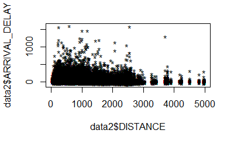

```r
data2<-data3[,grepl("ARRIVAL_DELAY|DISTANCE", colnames(data))]
plot(data2$DISTANCE,data2$ARRIVAL_DELAY,pch="*")
```

Then we perform clustering, choosing k as 3.

```r
data.kmeans<-kmeans(data2,3)
table(data3$DISTANCE_LEVEL,data.kmeans$cluster)
```

```
             1      2      3
  Long       0      0    290
  Mid        0      0  30833
  Short 163198 265357  28395
```

There should be a change in k-means value, observing the plot we obtain before, we can draw 2 different cluster from the graph,we can set the k-means value to 2.

```r
data.kmeans<-kmeans(data2,2)
table(data3$DISTANCE_LEVEL,data.kmeans$cluster)
```

[output not shown]

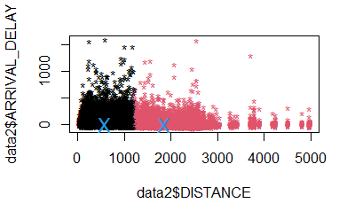

```r
plot(data2$DISTANCE,data2$ARRIVAL_DELAY,col=data.kmeans$cluster,pch="*")
points(data.kmeans$centers,pch="X",cex=1.5,col=4)
```

The label can also be cleaned, using 2 levels: short and long, instead of 3 levels can be more fit in the clusters.

```r
data3$DISTANCE_LEVEL[data3$DISTANCE<3000]<-"Short"
data3$DISTANCE_LEVEL[data3$DISTANCE>=3000]<-"Long"
table(data3$DISTANCE_LEVEL,data.kmeans$cluster)
```

```
             1      2
  Long       0    805
  Short 396111  91157
```

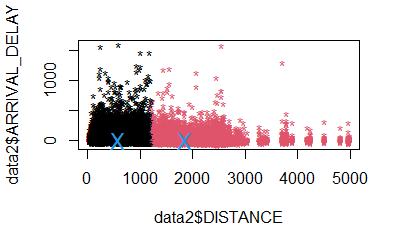

```r
plot(data2$DISTANCE,data2$ARRIVAL_DELAY,col=data.kmeans$cluster,pch="*")
points(data.kmeans$centers,pch="X",cex=1.5,col=4)
```

### K-Mediods

After using k-means, we can use the K-Mediods method to see if it has a better performance.

K-Mediods is a clustering algorithm that performs better when there are outsiders.

```r
data.clara<-clara(data2,2)
table(data3$DISTANCE_LEVEL,data.clara$clustering)
```

```
             1      2
  Long     805      0
  Short 214814 272454
```

[figure not shown]

```r
layout(matrix(c(1,2),1,2))
plot(data.clara)
layout(matrix(1))
```

But it also consumes large storage, so we’ll only perform the clustering on a small data set.

```r
data4<-sample(nrow(data3),0.01*nrow(data3))
data4<-data[data4,]


data4$DISTANCE_LEVEL[data4$DISTANCE<3000]<-"Short"
data4$DISTANCE_LEVEL[data4$DISTANCE>=3000]<-"Long"

data5<-data4
data5<-data5[,grepl("ARRIVAL_DELAY|DISTANCE", colnames(data5))]
data5<-data5[,-3]
ds<-dbscan(data5,eps=0.42,MinPts = 5)
table(ds$cluster,data4$DISTANCE_LEVEL)
```

```
    Long Short
  0   10  4870
```

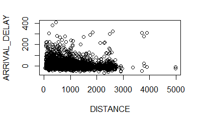

```r
plot(ds,data5)
```

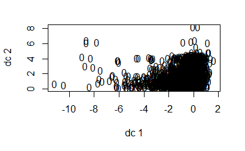

```r
plotcluster(data5,ds$cluster)
```

Eps stands for how large the area around one point and minpts stands for how much points should be find in the area to mark the centre point as important point.

The result is not ideal as using k-means, it’s because the data set is small, so density-based clustering can avoid choosing k-means values, but can only performs well on large data and high performance machines.